# Risk Factor Analysis

## Outcome Variable

**Outcome Variable:** pers_wast

## Predictor Variables

**Intervention Variable:** birthlen

**Adjustment Set:**

unadjusted

## Stratifying Variables

The analysis was stratified on these variable(s):

- agecat
- studyid
- country

## Data Summary

| agecat | studyid | country | birthlen | pers_wast | n_cell | n |
| --- | --- | --- | --- | --- | --- | --- |
| 0-24 months | ki0047075b-MAL-ED | BANGLADESH | >=50 cm | 0 | 26 | 241 |
| 0-24 months | ki0047075b-MAL-ED | BANGLADESH | >=50 cm | 1 | 3 | 241 |
| 0-24 months | ki0047075b-MAL-ED | BANGLADESH | <48 cm | 0 | 120 | 241 |
| 0-24 months | ki0047075b-MAL-ED | BANGLADESH | <48 cm | 1 | 8 | 241 |
| 0-24 months | ki0047075b-MAL-ED | BANGLADESH | [48-50) cm | 0 | 83 | 241 |
| 0-24 months | ki0047075b-MAL-ED | BANGLADESH | [48-50) cm | 1 | 1 | 241 |
| 0-24 months | ki0047075b-MAL-ED | BRAZIL | >=50 cm | 0 | 33 | 180 |
| 0-24 months | ki0047075b-MAL-ED | BRAZIL | >=50 cm | 1 | 0 | 180 |
| 0-24 months | ki0047075b-MAL-ED | BRAZIL | <48 cm | 0 | 72 | 180 |
| 0-24 months | ki0047075b-MAL-ED | BRAZIL | <48 cm | 1 | 1 | 180 |
| 0-24 months | ki0047075b-MAL-ED | BRAZIL | [48-50) cm | 0 | 74 | 180 |
| 0-24 months | ki0047075b-MAL-ED | BRAZIL | [48-50) cm | 1 | 0 | 180 |
| 0-24 months | ki0047075b-MAL-ED | INDIA | >=50 cm | 0 | 23 | 197 |
| 0-24 months | ki0047075b-MAL-ED | INDIA | >=50 cm | 1 | 1 | 197 |
| 0-24 months | ki0047075b-MAL-ED | INDIA | <48 cm | 0 | 97 | 197 |
| 0-24 months | ki0047075b-MAL-ED | INDIA | <48 cm | 1 | 7 | 197 |
| 0-24 months | ki0047075b-MAL-ED | INDIA | [48-50) cm | 0 | 61 | 197 |
| 0-24 months | ki0047075b-MAL-ED | INDIA | [48-50) cm | 1 | 8 | 197 |
| 0-24 months | ki0047075b-MAL-ED | NEPAL | >=50 cm | 0 | 37 | 172 |
| 0-24 months | ki0047075b-MAL-ED | NEPAL | >=50 cm | 1 | 1 | 172 |
| 0-24 months | ki0047075b-MAL-ED | NEPAL | <48 cm | 0 | 68 | 172 |
| 0-24 months | ki0047075b-MAL-ED | NEPAL | <48 cm | 1 | 0 | 172 |
| 0-24 months | ki0047075b-MAL-ED | NEPAL | [48-50) cm | 0 | 66 | 172 |
| 0-24 months | ki0047075b-MAL-ED | NEPAL | [48-50) cm | 1 | 0 | 172 |
| 0-24 months | ki0047075b-MAL-ED | PERU | >=50 cm | 0 | 32 | 271 |
| 0-24 months | ki0047075b-MAL-ED | PERU | >=50 cm | 1 | 0 | 271 |
| 0-24 months | ki0047075b-MAL-ED | PERU | <48 cm | 0 | 135 | 271 |
| 0-24 months | ki0047075b-MAL-ED | PERU | <48 cm | 1 | 1 | 271 |
| 0-24 months | ki0047075b-MAL-ED | PERU | [48-50) cm | 0 | 103 | 271 |
| 0-24 months | ki0047075b-MAL-ED | PERU | [48-50) cm | 1 | 0 | 271 |

[output cut: 390 more lines]

The following strata were considered:

- agecat: 0-24 months, studyid: ki0047075b-MAL-ED, country: BANGLADESH
- agecat: 0-24 months, studyid: ki0047075b-MAL-ED, country: BRAZIL
- agecat: 0-24 months, studyid: ki0047075b-MAL-ED, country: INDIA
- agecat: 0-24 months, studyid: ki0047075b-MAL-ED, country: NEPAL
- agecat: 0-24 months, studyid: ki0047075b-MAL-ED, country: PERU
- agecat: 0-24 months, studyid: ki0047075b-MAL-ED, country: SOUTH AFRICA
- agecat: 0-24 months, studyid: ki0047075b-MAL-ED, country: TANZANIA, UNITED REPUBLIC OF
- agecat: 0-24 months, studyid: ki1000108-CMC-V-BCS-2002, country: INDIA
- agecat: 0-24 months, studyid: ki1000108-IRC, country: INDIA
- agecat: 0-24 months, studyid: ki1000109-EE, country: PAKISTAN
- agecat: 0-24 months, studyid: ki1000109-ResPak, country: PAKISTAN
- agecat: 0-24 months, studyid: ki1000304b-SAS-CompFeed, country: INDIA
- agecat: 0-24 months, studyid: ki1017093-NIH-Birth, country: BANGLADESH
- agecat: 0-24 months, studyid: ki1017093b-PROVIDE, country: BANGLADESH
- agecat: 0-24 months, studyid: ki1017093c-NIH-Crypto, country: BANGLADESH
- agecat: 0-24 months, studyid: ki1101329-Keneba, country: GAMBIA
- agecat: 0-24 months, studyid: ki1114097-CMIN, country: BANGLADESH
- agecat: 0-24 months, studyid: ki1114097-CMIN, country: BRAZIL
- agecat: 0-24 months, studyid: ki1114097-CMIN, country: GUINEA-BISSAU
- agecat: 0-24 months, studyid: ki1114097-CMIN, country: PERU
- agecat: 0-24 months, studyid: ki1114097-CONTENT, country: PERU
- agecat: 0-24 months, studyid: ki1119695-PROBIT, country: BELARUS
- agecat: 0-24 months, studyid: ki1126311-ZVITAMBO, country: ZIMBABWE
- agecat: 0-24 months, studyid: ki1135781-COHORTS, country: GUATEMALA
- agecat: 0-24 months, studyid: ki1135781-COHORTS, country: INDIA
- agecat: 0-24 months, studyid: ki1135781-COHORTS, country: PHILIPPINES
- agecat: 0-24 months, studyid: kiGH5241-JiVitA-3, country: BANGLADESH
- agecat: 0-24 months, studyid: kiGH5241-JiVitA-4, country: BANGLADESH
- agecat: 0-6 months, studyid: ki0047075b-MAL-ED, country: BANGLADESH
- agecat: 0-6 months, studyid: ki0047075b-MAL-ED, country: BRAZIL
- agecat: 0-6 months, studyid: ki0047075b-MAL-ED, country: INDIA
- agecat: 0-6 months, studyid: ki0047075b-MAL-ED, country: NEPAL
- agecat: 0-6 months, studyid: ki0047075b-MAL-ED, country: PERU
- agecat: 0-6 months, studyid: ki0047075b-MAL-ED, country: SOUTH AFRICA
- agecat: 0-6 months, studyid: ki0047075b-MAL-ED, country: TANZANIA, UNITED REPUBLIC OF
- agecat: 0-6 months, studyid: ki1000108-CMC-V-BCS-2002, country: INDIA
- agecat: 0-6 months, studyid: ki1000108-IRC, country: INDIA
- agecat: 0-6 months, studyid: ki1000109-EE, country: PAKISTAN
- agecat: 0-6 months, studyid: ki1000109-ResPak, country: PAKISTAN
- agecat: 0-6 months, studyid: ki1017093b-PROVIDE, country: BANGLADESH
- agecat: 0-6 months, studyid: ki1101329-Keneba, country: GAMBIA
- agecat: 0-6 months, studyid: ki1114097-CMIN, country: BANGLADESH
- agecat: 0-6 months, studyid: ki1114097-CMIN, country: PERU
- agecat: 0-6 months, studyid: ki1114097-CONTENT, country: PERU
- agecat: 6-24 months, studyid: ki0047075b-MAL-ED, country: BANGLADESH
- agecat: 6-24 months, studyid: ki0047075b-MAL-ED, country: BRAZIL
- agecat: 6-24 months, studyid: ki0047075b-MAL-ED, country: INDIA
- agecat: 6-24 months, studyid: ki0047075b-MAL-ED, country: NEPAL
- agecat: 6-24 months, studyid: ki0047075b-MAL-ED, country: PERU
- agecat: 6-24 months, studyid: ki0047075b-MAL-ED, country: SOUTH AFRICA
- agecat: 6-24 months, studyid: ki0047075b-MAL-ED, country: TANZANIA, UNITED REPUBLIC OF
- agecat: 6-24 months, studyid: ki1000108-CMC-V-BCS-2002, country: INDIA
- agecat: 6-24 months, studyid: ki1000108-IRC, country: INDIA
- agecat: 6-24 months, studyid: ki1000109-EE, country: PAKISTAN
- agecat: 6-24 months, studyid: ki1000109-ResPak, country: PAKISTAN
- agecat: 6-24 months, studyid: ki1000304b-SAS-CompFeed, country: INDIA
- agecat: 6-24 months, studyid: ki1017093-NIH-Birth, country: BANGLADESH
- agecat: 6-24 months, studyid: ki1017093b-PROVIDE, country: BANGLADESH
- agecat: 6-24 months, studyid: ki1017093c-NIH-Crypto, country: BANGLADESH
- agecat: 6-24 months, studyid: ki1101329-Keneba, country: GAMBIA
- agecat: 6-24 months, studyid: ki1114097-CMIN, country: BANGLADESH
- agecat: 6-24 months, studyid: ki1114097-CMIN, country: BRAZIL
- agecat: 6-24 months, studyid: ki1114097-CMIN, country: GUINEA-BISSAU
- agecat: 6-24 months, studyid: ki1114097-CMIN, country: PERU
- agecat: 6-24 months, studyid: ki1114097-CONTENT, country: PERU
- agecat: 6-24 months, studyid: ki1119695-PROBIT, country: BELARUS
- agecat: 6-24 months, studyid: ki1126311-ZVITAMBO, country: ZIMBABWE
- agecat: 6-24 months, studyid: ki1135781-COHORTS, country: GUATEMALA
- agecat: 6-24 months, studyid: ki1135781-COHORTS, country: PHILIPPINES
- agecat: 6-24 months, studyid: kiGH5241-JiVitA-4, country: BANGLADESH

### Dropped Strata

Some strata were dropped due to rare outcomes:

- agecat: 0-24 months, studyid: ki0047075b-MAL-ED, country: BANGLADESH
- agecat: 0-24 months, studyid: ki0047075b-MAL-ED, country: BRAZIL
- agecat: 0-24 months, studyid: ki0047075b-MAL-ED, country: INDIA
- agecat: 0-24 months, studyid: ki0047075b-MAL-ED, country: NEPAL
- agecat: 0-24 months, studyid: ki0047075b-MAL-ED, country: PERU
- agecat: 0-24 months, studyid: ki0047075b-MAL-ED, country: SOUTH AFRICA
- agecat: 0-24 months, studyid: ki0047075b-MAL-ED, country: TANZANIA, UNITED REPUBLIC OF
- agecat: 0-24 months, studyid: ki1000108-CMC-V-BCS-2002, country: INDIA
- agecat: 0-24 months, studyid: ki1000109-EE, country: PAKISTAN
- agecat: 0-24 months, studyid: ki1000109-ResPak, country: PAKISTAN
- agecat: 0-24 months, studyid: ki1017093-NIH-Birth, country: BANGLADESH
- agecat: 0-24 months, studyid: ki1017093b-PROVIDE, country: BANGLADESH
- agecat: 0-24 months, studyid: ki1017093c-NIH-Crypto, country: BANGLADESH
- agecat: 0-24 months, studyid: ki1114097-CMIN, country: BANGLADESH
- agecat: 0-24 months, studyid: ki1114097-CMIN, country: BRAZIL
- agecat: 0-24 months, studyid: ki1114097-CMIN, country: GUINEA-BISSAU
- agecat: 0-24 months, studyid: ki1114097-CMIN, country: PERU
- agecat: 0-24 months, studyid: ki1114097-CONTENT, country: PERU
- agecat: 0-24 months, studyid: ki1119695-PROBIT, country: BELARUS
- agecat: 0-6 months, studyid: ki0047075b-MAL-ED, country: BANGLADESH
- agecat: 0-6 months, studyid: ki0047075b-MAL-ED, country: BRAZIL
- agecat: 0-6 months, studyid: ki0047075b-MAL-ED, country: INDIA
- agecat: 0-6 months, studyid: ki0047075b-MAL-ED, country: NEPAL
- agecat: 0-6 months, studyid: ki0047075b-MAL-ED, country: PERU
- agecat: 0-6 months, studyid: ki0047075b-MAL-ED, country: SOUTH AFRICA
- agecat: 0-6 months, studyid: ki0047075b-MAL-ED, country: TANZANIA, UNITED REPUBLIC OF
- agecat: 0-6 months, studyid: ki1000108-CMC-V-BCS-2002, country: INDIA
- agecat: 0-6 months, studyid: ki1000109-EE, country: PAKISTAN
- agecat: 0-6 months, studyid: ki1000109-ResPak, country: PAKISTAN
- agecat: 0-6 months, studyid: ki1017093b-PROVIDE, country: BANGLADESH
- agecat: 0-6 months, studyid: ki1114097-CMIN, country: BANGLADESH
- agecat: 0-6 months, studyid: ki1114097-CMIN, country: PERU
- agecat: 0-6 months, studyid: ki1114097-CONTENT, country: PERU
- agecat: 6-24 months, studyid: ki0047075b-MAL-ED, country: BANGLADESH
- agecat: 6-24 months, studyid: ki0047075b-MAL-ED, country: BRAZIL
- agecat: 6-24 months, studyid: ki0047075b-MAL-ED, country: INDIA
- agecat: 6-24 months, studyid: ki0047075b-MAL-ED, country: NEPAL
- agecat: 6-24 months, studyid: ki0047075b-MAL-ED, country: PERU
- agecat: 6-24 months, studyid: ki0047075b-MAL-ED, country: SOUTH AFRICA
- agecat: 6-24 months, studyid: ki0047075b-MAL-ED, country: TANZANIA, UNITED REPUBLIC OF
- agecat: 6-24 months, studyid: ki1000108-CMC-V-BCS-2002, country: INDIA
- agecat: 6-24 months, studyid: ki1000109-EE, country: PAKISTAN
- agecat: 6-24 months, studyid: ki1000109-ResPak, country: PAKISTAN
- agecat: 6-24 months, studyid: ki1017093-NIH-Birth, country: BANGLADESH
- agecat: 6-24 months, studyid: ki1017093c-NIH-Crypto, country: BANGLADESH
- agecat: 6-24 months, studyid: ki1114097-CMIN, country: BANGLADESH
- agecat: 6-24 months, studyid: ki1114097-CMIN, country: BRAZIL
- agecat: 6-24 months, studyid: ki1114097-CMIN, country: GUINEA-BISSAU
- agecat: 6-24 months, studyid: ki1114097-CMIN, country: PERU
- agecat: 6-24 months, studyid: ki1114097-CONTENT, country: PERU
- agecat: 6-24 months, studyid: ki1119695-PROBIT, country: BELARUS
- agecat: 6-24 months, studyid: ki1135781-COHORTS, country: GUATEMALA

## Methods Detail

We’re interested in the causal parameters $E[Y_a]$ for all values of $a \in \mathcal{A}$. These parameters represent the mean outcome if, possibly contrary to fact, we intervened to set all units to have $A=a$. Under the randomization and positivity assumptions, these are identified by the statistical parameters $\psi_a=E_W[E_{Y|A,W}(Y|A=a,W)]$. In addition, we’re interested in the mean of $Y$, $E[Y]$ under no intervention (the observed mean). We will estimate these parameters by using SuperLearner to fit the relevant likelihood factors – $E_{Y|A,W}(Y|A=a,W)$ and $p(A=a|W)$, and then updating our likelihood fit using a joint TMLE.

For unadjusted analyses ($W=\{\}$), initial likelihoods were estimated using Lrnr_glm to estimate the simple $E(Y|A)$ and Lrnr_mean to estimate $p(A)$. For adjusted analyses, a small library containing Lrnr_glmnet, Lrnr_xgboost, and Lrnr_mean was used.

Having estimated these parameters, we will then use the delta method to estimate relative risks and attributable risks relative to a prespecified baseline level of $A$.

# Results Detail

## Results Plots

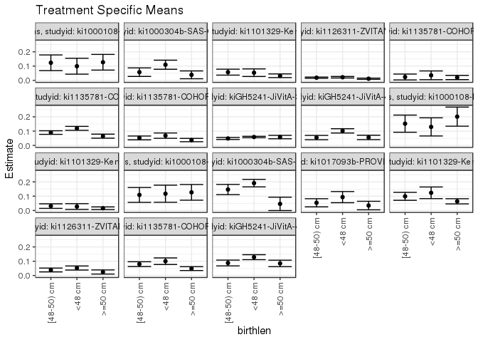

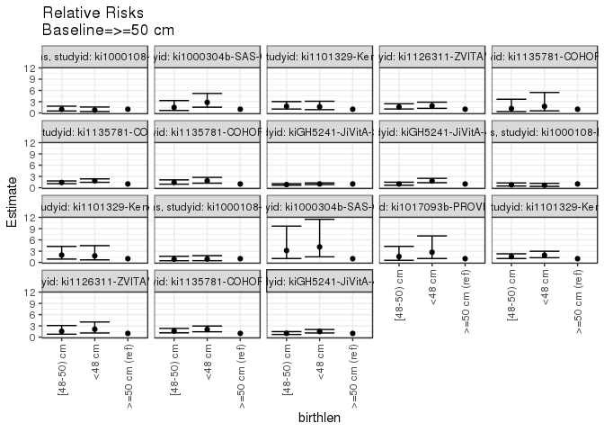

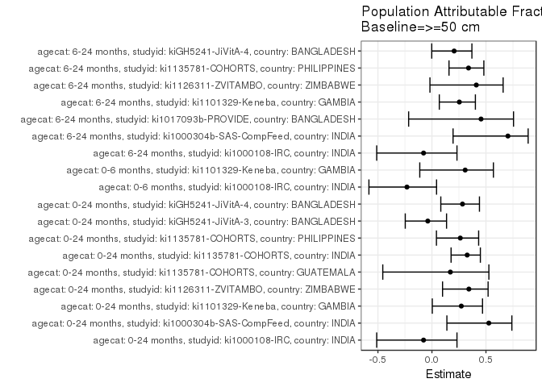

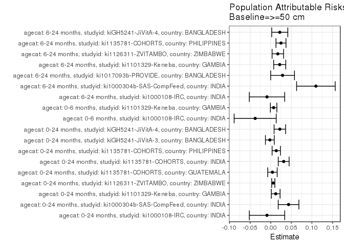

## Results Table

### Parameter: TSM

| agecat | studyid | country | intervention_level | baseline_level | estimate | ci_lower | ci_upper |
| --- | --- | --- | --- | --- | --- | --- | --- |
| 0-24 months | ki1000108-IRC | INDIA | >=50 cm | NA | 0.1267606 | 0.0719684 | 0.1815528 |
| 0-24 months | ki1000108-IRC | INDIA | <48 cm | NA | 0.0990991 | 0.0434426 | 0.1547556 |
| 0-24 months | ki1000108-IRC | INDIA | [48-50) cm | NA | 0.1231884 | 0.0682846 | 0.1780922 |
| 0-24 months | ki1000304b-SAS-CompFeed | INDIA | >=50 cm | NA | 0.0388350 | 0.0114714 | 0.0661985 |
| 0-24 months | ki1000304b-SAS-CompFeed | INDIA | <48 cm | NA | 0.1095506 | 0.0778598 | 0.1412413 |
| 0-24 months | ki1000304b-SAS-CompFeed | INDIA | [48-50) cm | NA | 0.0574713 | 0.0276190 | 0.0873235 |
| 0-24 months | ki1101329-Keneba | GAMBIA | >=50 cm | NA | 0.0323887 | 0.0196381 | 0.0451393 |
| 0-24 months | ki1101329-Keneba | GAMBIA | <48 cm | NA | 0.0537634 | 0.0272886 | 0.0802383 |
| 0-24 months | ki1101329-Keneba | GAMBIA | [48-50) cm | NA | 0.0576132 | 0.0368903 | 0.0783360 |
| 0-24 months | ki1126311-ZVITAMBO | ZIMBABWE | >=50 cm | NA | 0.0117424 | 0.0076330 | 0.0158519 |
| 0-24 months | ki1126311-ZVITAMBO | ZIMBABWE | <48 cm | NA | 0.0220638 | 0.0167592 | 0.0273684 |
| 0-24 months | ki1126311-ZVITAMBO | ZIMBABWE | [48-50) cm | NA | 0.0188576 | 0.0144500 | 0.0232652 |
| 0-24 months | ki1135781-COHORTS | GUATEMALA | >=50 cm | NA | 0.0201729 | 0.0053698 | 0.0349760 |
| 0-24 months | ki1135781-COHORTS | GUATEMALA | <48 cm | NA | 0.0354610 | 0.0049129 | 0.0660091 |
| 0-24 months | ki1135781-COHORTS | GUATEMALA | [48-50) cm | NA | 0.0236967 | 0.0031589 | 0.0442345 |
| 0-24 months | ki1135781-COHORTS | INDIA | >=50 cm | NA | 0.0648464 | 0.0507467 | 0.0789461 |
| 0-24 months | ki1135781-COHORTS | INDIA | <48 cm | NA | 0.1194523 | 0.1056389 | 0.1332657 |
| 0-24 months | ki1135781-COHORTS | INDIA | [48-50) cm | NA | 0.0900354 | 0.0774170 | 0.1026538 |
| 0-24 months | ki1135781-COHORTS | PHILIPPINES | >=50 cm | NA | 0.0376085 | 0.0260272 | 0.0491897 |
| 0-24 months | ki1135781-COHORTS | PHILIPPINES | <48 cm | NA | 0.0684736 | 0.0497743 | 0.0871729 |
| 0-24 months | ki1135781-COHORTS | PHILIPPINES | [48-50) cm | NA | 0.0525328 | 0.0391378 | 0.0659279 |
| 0-24 months | kiGH5241-JiVitA-3 | BANGLADESH | >=50 cm | NA | 0.0585182 | 0.0465238 | 0.0705125 |
| 0-24 months | kiGH5241-JiVitA-3 | BANGLADESH | <48 cm | NA | 0.0588726 | 0.0538280 | 0.0639171 |
| 0-24 months | kiGH5241-JiVitA-3 | BANGLADESH | [48-50) cm | NA | 0.0487546 | 0.0415411 | 0.0559681 |
| 0-24 months | kiGH5241-JiVitA-4 | BANGLADESH | >=50 cm | NA | 0.0559265 | 0.0404783 | 0.0713748 |
| 0-24 months | kiGH5241-JiVitA-4 | BANGLADESH | <48 cm | NA | 0.1018692 | 0.0868723 | 0.1168661 |
| 0-24 months | kiGH5241-JiVitA-4 | BANGLADESH | [48-50) cm | NA | 0.0550373 | 0.0399830 | 0.0700916 |
| 0-6 months | ki1000108-IRC | INDIA | >=50 cm | NA | 0.2014388 | 0.1346766 | 0.2682011 |
| 0-6 months | ki1000108-IRC | INDIA | <48 cm | NA | 0.1296296 | 0.0661981 | 0.1930612 |
| 0-6 months | ki1000108-IRC | INDIA | [48-50) cm | NA | 0.1521739 | 0.0921676 | 0.2121802 |
| 0-6 months | ki1101329-Keneba | GAMBIA | >=50 cm | NA | 0.0157143 | 0.0064979 | 0.0249307 |
| 0-6 months | ki1101329-Keneba | GAMBIA | <48 cm | NA | 0.0275591 | 0.0074195 | 0.0476986 |
| 0-6 months | ki1101329-Keneba | GAMBIA | [48-50) cm | NA | 0.0307018 | 0.0148627 | 0.0465408 |
| 6-24 months | ki1000108-IRC | INDIA | >=50 cm | NA | 0.1267606 | 0.0719684 | 0.1815528 |
| 6-24 months | ki1000108-IRC | INDIA | <48 cm | NA | 0.1171171 | 0.0572202 | 0.1770140 |
| 6-24 months | ki1000108-IRC | INDIA | [48-50) cm | NA | 0.1086957 | 0.0566980 | 0.1606933 |
| 6-24 months | ki1000304b-SAS-CompFeed | INDIA | >=50 cm | NA | 0.0462428 | -0.0003954 | 0.0928810 |
| 6-24 months | ki1000304b-SAS-CompFeed | INDIA | <48 cm | NA | 0.1912226 | 0.1649733 | 0.2174718 |
| 6-24 months | ki1000304b-SAS-CompFeed | INDIA | [48-50) cm | NA | 0.1465969 | 0.1109065 | 0.1822872 |
| 6-24 months | ki1017093b-PROVIDE | BANGLADESH | >=50 cm | NA | 0.0344828 | 0.0047588 | 0.0642067 |
| 6-24 months | ki1017093b-PROVIDE | BANGLADESH | <48 cm | NA | 0.0934579 | 0.0544274 | 0.1324885 |
| 6-24 months | ki1017093b-PROVIDE | BANGLADESH | [48-50) cm | NA | 0.0537190 | 0.0252891 | 0.0821490 |
| 6-24 months | ki1101329-Keneba | GAMBIA | >=50 cm | NA | 0.0640114 | 0.0459109 | 0.0821118 |
| 6-24 months | ki1101329-Keneba | GAMBIA | <48 cm | NA | 0.1235060 | 0.0827881 | 0.1642238 |
| 6-24 months | ki1101329-Keneba | GAMBIA | [48-50) cm | NA | 0.0988764 | 0.0711329 | 0.1266199 |
| 6-24 months | ki1126311-ZVITAMBO | ZIMBABWE | >=50 cm | NA | 0.0246637 | 0.0102662 | 0.0390611 |
| 6-24 months | ki1126311-ZVITAMBO | ZIMBABWE | <48 cm | NA | 0.0524659 | 0.0383068 | 0.0666250 |
| 6-24 months | ki1126311-ZVITAMBO | ZIMBABWE | [48-50) cm | NA | 0.0387985 | 0.0254052 | 0.0521918 |
| 6-24 months | ki1135781-COHORTS | PHILIPPINES | >=50 cm | NA | 0.0484536 | 0.0349384 | 0.0619688 |
| 6-24 months | ki1135781-COHORTS | PHILIPPINES | <48 cm | NA | 0.1001517 | 0.0772271 | 0.1230763 |
| 6-24 months | ki1135781-COHORTS | PHILIPPINES | [48-50) cm | NA | 0.0796020 | 0.0628642 | 0.0963397 |
| 6-24 months | kiGH5241-JiVitA-4 | BANGLADESH | >=50 cm | NA | 0.0847308 | 0.0621855 | 0.1072761 |
| 6-24 months | kiGH5241-JiVitA-4 | BANGLADESH | <48 cm | NA | 0.1282176 | 0.1108252 | 0.1456099 |
| 6-24 months | kiGH5241-JiVitA-4 | BANGLADESH | [48-50) cm | NA | 0.0876339 | 0.0673448 | 0.1079230 |

### Parameter: E(Y)

| agecat | studyid | country | intervention_level | baseline_level | estimate | ci_lower | ci_upper |
| --- | --- | --- | --- | --- | --- | --- | --- |
| 0-24 months | ki1000108-IRC | INDIA | NA | NA | 0.1176471 | 0.0856708 | 0.1496233 |
| 0-24 months | ki1000304b-SAS-CompFeed | INDIA | NA | NA | 0.0820399 | 0.0573937 | 0.1066861 |
| 0-24 months | ki1101329-Keneba | GAMBIA | NA | NA | 0.0444887 | 0.0340722 | 0.0549052 |
| 0-24 months | ki1126311-ZVITAMBO | ZIMBABWE | NA | NA | 0.0178475 | 0.0151485 | 0.0205464 |
| 0-24 months | ki1135781-COHORTS | GUATEMALA | NA | NA | 0.0243205 | 0.0128927 | 0.0357482 |
| 0-24 months | ki1135781-COHORTS | INDIA | NA | NA | 0.0962597 | 0.0882935 | 0.1042259 |
| 0-24 months | ki1135781-COHORTS | PHILIPPINES | NA | NA | 0.0509986 | 0.0428544 | 0.0591428 |
| 0-24 months | kiGH5241-JiVitA-3 | BANGLADESH | NA | NA | 0.0563589 | 0.0522997 | 0.0604181 |
| 0-24 months | kiGH5241-JiVitA-4 | BANGLADESH | NA | NA | 0.0780045 | 0.0689447 | 0.0870643 |
| 0-6 months | ki1000108-IRC | INDIA | NA | NA | 0.1636364 | 0.1266348 | 0.2006379 |
| 0-6 months | ki1101329-Keneba | GAMBIA | NA | NA | 0.0226950 | 0.0149187 | 0.0304713 |
| 6-24 months | ki1000108-IRC | INDIA | NA | NA | 0.1176471 | 0.0856708 | 0.1496233 |
| 6-24 months | ki1000304b-SAS-CompFeed | INDIA | NA | NA | 0.1559095 | 0.1400659 | 0.1717530 |
| 6-24 months | ki1017093b-PROVIDE | BANGLADESH | NA | NA | 0.0632280 | 0.0437545 | 0.0827015 |
| 6-24 months | ki1101329-Keneba | GAMBIA | NA | NA | 0.0857756 | 0.0710963 | 0.1004548 |
| 6-24 months | ki1126311-ZVITAMBO | ZIMBABWE | NA | NA | 0.0418562 | 0.0334823 | 0.0502301 |
| 6-24 months | ki1135781-COHORTS | PHILIPPINES | NA | NA | 0.0732726 | 0.0633192 | 0.0832259 |
| 6-24 months | kiGH5241-JiVitA-4 | BANGLADESH | NA | NA | 0.1066603 | 0.0950623 | 0.1182584 |

### Parameter: RR

| agecat | studyid | country | intervention_level | baseline_level | estimate | ci_lower | ci_upper |
| --- | --- | --- | --- | --- | --- | --- | --- |
| 0-24 months | ki1000108-IRC | INDIA | >=50 cm | >=50 cm | 1.0000000 | 1.0000000 | 1.000000 |
| 0-24 months | ki1000108-IRC | INDIA | <48 cm | >=50 cm | 0.7817818 | 0.3848567 | 1.588079 |
| 0-24 months | ki1000108-IRC | INDIA | [48-50) cm | >=50 cm | 0.9718196 | 0.5223305 | 1.808115 |
| 0-24 months | ki1000304b-SAS-CompFeed | INDIA | >=50 cm | >=50 cm | 1.0000000 | 1.0000000 | 1.000000 |
| 0-24 months | ki1000304b-SAS-CompFeed | INDIA | <48 cm | >=50 cm | 2.8209264 | 1.5294182 | 5.203041 |
| 0-24 months | ki1000304b-SAS-CompFeed | INDIA | [48-50) cm | >=50 cm | 1.4798847 | 0.6628767 | 3.303871 |
| 0-24 months | ki1101329-Keneba | GAMBIA | >=50 cm | >=50 cm | 1.0000000 | 1.0000000 | 1.000000 |
| 0-24 months | ki1101329-Keneba | GAMBIA | <48 cm | >=50 cm | 1.6599462 | 0.8836747 | 3.118140 |
| 0-24 months | ki1101329-Keneba | GAMBIA | [48-50) cm | >=50 cm | 1.7788066 | 1.0436165 | 3.031911 |
| 0-24 months | ki1126311-ZVITAMBO | ZIMBABWE | >=50 cm | >=50 cm | 1.0000000 | 1.0000000 | 1.000000 |
| 0-24 months | ki1126311-ZVITAMBO | ZIMBABWE | <48 cm | >=50 cm | 1.8789830 | 1.2289244 | 2.872900 |
| 0-24 months | ki1126311-ZVITAMBO | ZIMBABWE | [48-50) cm | >=50 cm | 1.6059385 | 1.0542918 | 2.446228 |
| 0-24 months | ki1135781-COHORTS | GUATEMALA | >=50 cm | >=50 cm | 1.0000000 | 1.0000000 | 1.000000 |
| 0-24 months | ki1135781-COHORTS | GUATEMALA | <48 cm | >=50 cm | 1.7578521 | 0.5669193 | 5.450589 |
| 0-24 months | ki1135781-COHORTS | GUATEMALA | [48-50) cm | >=50 cm | 1.1746784 | 0.3773324 | 3.656907 |
| 0-24 months | ki1135781-COHORTS | INDIA | >=50 cm | >=50 cm | 1.0000000 | 1.0000000 | 1.000000 |
| 0-24 months | ki1135781-COHORTS | INDIA | <48 cm | >=50 cm | 1.8420804 | 1.4399738 | 2.356474 |
| 0-24 months | ki1135781-COHORTS | INDIA | [48-50) cm | >=50 cm | 1.3884408 | 1.0719666 | 1.798347 |
| 0-24 months | ki1135781-COHORTS | PHILIPPINES | >=50 cm | >=50 cm | 1.0000000 | 1.0000000 | 1.000000 |
| 0-24 months | ki1135781-COHORTS | PHILIPPINES | <48 cm | >=50 cm | 1.8206957 | 1.2063869 | 2.747819 |
| 0-24 months | ki1135781-COHORTS | PHILIPPINES | [48-50) cm | >=50 cm | 1.3968346 | 0.9365072 | 2.083430 |
| 0-24 months | kiGH5241-JiVitA-3 | BANGLADESH | >=50 cm | >=50 cm | 1.0000000 | 1.0000000 | 1.000000 |
| 0-24 months | kiGH5241-JiVitA-3 | BANGLADESH | <48 cm | >=50 cm | 1.0060562 | 0.8094898 | 1.250354 |
| 0-24 months | kiGH5241-JiVitA-3 | BANGLADESH | [48-50) cm | >=50 cm | 0.8331538 | 0.6496214 | 1.068538 |
| 0-24 months | kiGH5241-JiVitA-4 | BANGLADESH | >=50 cm | >=50 cm | 1.0000000 | 1.0000000 | 1.000000 |
| 0-24 months | kiGH5241-JiVitA-4 | BANGLADESH | <48 cm | >=50 cm | 1.8214814 | 1.3306287 | 2.493404 |
| 0-24 months | kiGH5241-JiVitA-4 | BANGLADESH | [48-50) cm | >=50 cm | 0.9841000 | 0.6629762 | 1.460766 |
| 0-6 months | ki1000108-IRC | INDIA | >=50 cm | >=50 cm | 1.0000000 | 1.0000000 | 1.000000 |
| 0-6 months | ki1000108-IRC | INDIA | <48 cm | >=50 cm | 0.6435185 | 0.3563616 | 1.162067 |
| 0-6 months | ki1000108-IRC | INDIA | [48-50) cm | >=50 cm | 0.7554348 | 0.4513233 | 1.264463 |
| 0-6 months | ki1101329-Keneba | GAMBIA | >=50 cm | >=50 cm | 1.0000000 | 1.0000000 | 1.000000 |
| 0-6 months | ki1101329-Keneba | GAMBIA | <48 cm | >=50 cm | 1.7537581 | 0.6871083 | 4.476248 |
| 0-6 months | ki1101329-Keneba | GAMBIA | [48-50) cm | >=50 cm | 1.9537480 | 0.8946155 | 4.266784 |
| 6-24 months | ki1000108-IRC | INDIA | >=50 cm | >=50 cm | 1.0000000 | 1.0000000 | 1.000000 |
| 6-24 months | ki1000108-IRC | INDIA | <48 cm | >=50 cm | 0.9239239 | 0.4729571 | 1.804890 |
| 6-24 months | ki1000108-IRC | INDIA | [48-50) cm | >=50 cm | 0.8574879 | 0.4500102 | 1.633931 |
| 6-24 months | ki1000304b-SAS-CompFeed | INDIA | >=50 cm | >=50 cm | 1.0000000 | 1.0000000 | 1.000000 |
| 6-24 months | ki1000304b-SAS-CompFeed | INDIA | <48 cm | >=50 cm | 4.1351880 | 1.4893093 | 11.481685 |
| 6-24 months | ki1000304b-SAS-CompFeed | INDIA | [48-50) cm | >=50 cm | 3.1701570 | 1.0389523 | 9.673106 |
| 6-24 months | ki1017093b-PROVIDE | BANGLADESH | >=50 cm | >=50 cm | 1.0000000 | 1.0000000 | 1.000000 |
| 6-24 months | ki1017093b-PROVIDE | BANGLADESH | <48 cm | >=50 cm | 2.7102804 | 1.0399963 | 7.063121 |
| 6-24 months | ki1017093b-PROVIDE | BANGLADESH | [48-50) cm | >=50 cm | 1.5578512 | 0.5665507 | 4.283642 |
| 6-24 months | ki1101329-Keneba | GAMBIA | >=50 cm | >=50 cm | 1.0000000 | 1.0000000 | 1.000000 |
| 6-24 months | ki1101329-Keneba | GAMBIA | <48 cm | >=50 cm | 1.9294378 | 1.2496837 | 2.978938 |
| 6-24 months | ki1101329-Keneba | GAMBIA | [48-50) cm | >=50 cm | 1.5446692 | 1.0371254 | 2.300592 |
| 6-24 months | ki1126311-ZVITAMBO | ZIMBABWE | >=50 cm | >=50 cm | 1.0000000 | 1.0000000 | 1.000000 |
| 6-24 months | ki1126311-ZVITAMBO | ZIMBABWE | <48 cm | >=50 cm | 2.1272536 | 1.1181962 | 4.046882 |
| 6-24 months | ki1126311-ZVITAMBO | ZIMBABWE | [48-50) cm | >=50 cm | 1.5731027 | 0.7984114 | 3.099470 |
| 6-24 months | ki1135781-COHORTS | PHILIPPINES | >=50 cm | >=50 cm | 1.0000000 | 1.0000000 | 1.000000 |
| 6-24 months | ki1135781-COHORTS | PHILIPPINES | <48 cm | >=50 cm | 2.0669615 | 1.4408762 | 2.965092 |
| 6-24 months | ki1135781-COHORTS | PHILIPPINES | [48-50) cm | >=50 cm | 1.6428496 | 1.1584995 | 2.329699 |
| 6-24 months | kiGH5241-JiVitA-4 | BANGLADESH | >=50 cm | >=50 cm | 1.0000000 | 1.0000000 | 1.000000 |
| 6-24 months | kiGH5241-JiVitA-4 | BANGLADESH | <48 cm | >=50 cm | 1.5132346 | 1.1199870 | 2.044558 |
| 6-24 months | kiGH5241-JiVitA-4 | BANGLADESH | [48-50) cm | >=50 cm | 1.0342624 | 0.7239277 | 1.477632 |

### Parameter: PAR

| agecat | studyid | country | intervention_level | baseline_level | estimate | ci_lower | ci_upper |
| --- | --- | --- | --- | --- | --- | --- | --- |
| 0-24 months | ki1000108-IRC | INDIA | >=50 cm | NA | -0.0091135 | -0.0520559 | 0.0338289 |
| 0-24 months | ki1000304b-SAS-CompFeed | INDIA | >=50 cm | NA | 0.0432050 | 0.0181178 | 0.0682921 |
| 0-24 months | ki1101329-Keneba | GAMBIA | >=50 cm | NA | 0.0121000 | 0.0015599 | 0.0226402 |
| 0-24 months | ki1126311-ZVITAMBO | ZIMBABWE | >=50 cm | NA | 0.0061051 | 0.0022936 | 0.0099165 |
| 0-24 months | ki1135781-COHORTS | GUATEMALA | >=50 cm | NA | 0.0041475 | -0.0073486 | 0.0156437 |
| 0-24 months | ki1135781-COHORTS | INDIA | >=50 cm | NA | 0.0314133 | 0.0182304 | 0.0445962 |
| 0-24 months | ki1135781-COHORTS | PHILIPPINES | >=50 cm | NA | 0.0133901 | 0.0033280 | 0.0234522 |
| 0-24 months | kiGH5241-JiVitA-3 | BANGLADESH | >=50 cm | NA | -0.0021592 | -0.0128906 | 0.0085721 |
| 0-24 months | kiGH5241-JiVitA-4 | BANGLADESH | >=50 cm | NA | 0.0220780 | 0.0081076 | 0.0360483 |
| 0-6 months | ki1000108-IRC | INDIA | >=50 cm | NA | -0.0378025 | -0.0888698 | 0.0132648 |
| 0-6 months | ki1101329-Keneba | GAMBIA | >=50 cm | NA | 0.0069807 | -0.0008342 | 0.0147957 |
| 6-24 months | ki1000108-IRC | INDIA | >=50 cm | NA | -0.0091135 | -0.0520559 | 0.0338289 |
| 6-24 months | ki1000304b-SAS-CompFeed | INDIA | >=50 cm | NA | 0.1096667 | 0.0628113 | 0.1565221 |
| 6-24 months | ki1017093b-PROVIDE | BANGLADESH | >=50 cm | NA | 0.0287452 | -0.0001756 | 0.0576659 |
| 6-24 months | ki1101329-Keneba | GAMBIA | >=50 cm | NA | 0.0217642 | 0.0071409 | 0.0363874 |
| 6-24 months | ki1126311-ZVITAMBO | ZIMBABWE | >=50 cm | NA | 0.0171926 | 0.0032898 | 0.0310953 |
| 6-24 months | ki1135781-COHORTS | PHILIPPINES | >=50 cm | NA | 0.0248190 | 0.0126865 | 0.0369514 |
| 6-24 months | kiGH5241-JiVitA-4 | BANGLADESH | >=50 cm | NA | 0.0219295 | 0.0023794 | 0.0414797 |

### Parameter: PAF

| agecat | studyid | country | intervention_level | baseline_level | estimate | ci_lower | ci_upper |
| --- | --- | --- | --- | --- | --- | --- | --- |
| 0-24 months | ki1000108-IRC | INDIA | >=50 cm | NA | -0.0774648 | -0.5113100 | 0.2318384 |
| 0-24 months | ki1000304b-SAS-CompFeed | INDIA | >=50 cm | NA | 0.5266333 | 0.1384809 | 0.7399060 |
| 0-24 months | ki1101329-Keneba | GAMBIA | >=50 cm | NA | 0.2719802 | 0.0031447 | 0.4683152 |
| 0-24 months | ki1126311-ZVITAMBO | ZIMBABWE | >=50 cm | NA | 0.3420684 | 0.0983224 | 0.5199238 |
| 0-24 months | ki1135781-COHORTS | GUATEMALA | >=50 cm | NA | 0.1705374 | -0.4549860 | 0.5271375 |
| 0-24 months | ki1135781-COHORTS | INDIA | >=50 cm | NA | 0.3263391 | 0.1772877 | 0.4483867 |
| 0-24 months | ki1135781-COHORTS | PHILIPPINES | >=50 cm | NA | 0.2625581 | 0.0417437 | 0.4324894 |
| 0-24 months | kiGH5241-JiVitA-3 | BANGLADESH | >=50 cm | NA | -0.0383121 | -0.2468581 | 0.1353531 |
| 0-24 months | kiGH5241-JiVitA-4 | BANGLADESH | >=50 cm | NA | 0.2830347 | 0.0821573 | 0.4399484 |
| 0-6 months | ki1000108-IRC | INDIA | >=50 cm | NA | -0.2310152 | -0.5832892 | 0.0428796 |
| 0-6 months | ki1101329-Keneba | GAMBIA | >=50 cm | NA | 0.3075893 | -0.1125539 | 0.5690702 |
| 6-24 months | ki1000108-IRC | INDIA | >=50 cm | NA | -0.0774648 | -0.5113100 | 0.2318384 |
| 6-24 months | ki1000304b-SAS-CompFeed | INDIA | >=50 cm | NA | 0.7033998 | 0.1955708 | 0.8906409 |
| 6-24 months | ki1017093b-PROVIDE | BANGLADESH | >=50 cm | NA | 0.4546279 | -0.2155353 | 0.7553089 |
| 6-24 months | ki1101329-Keneba | GAMBIA | >=50 cm | NA | 0.2537340 | 0.0682486 | 0.4022945 |
| 6-24 months | ki1126311-ZVITAMBO | ZIMBABWE | >=50 cm | NA | 0.4107526 | -0.0183435 | 0.6590418 |
| 6-24 months | ki1135781-COHORTS | PHILIPPINES | >=50 cm | NA | 0.3387212 | 0.1580195 | 0.4806416 |
| 6-24 months | kiGH5241-JiVitA-4 | BANGLADESH | >=50 cm | NA | 0.2056016 | -0.0017540 | 0.3700362 |